# Diversity measures

George Cresswell

10/02/2022

## Diversity measurements in the Longitudinal Metastasis Cohort

### Libraries

We use lmerTest to perform the linear mixed models. It allows us to test if there is a significant change whilst controlling for different patients.

```r
# Libraries
library(ggplot2)
library(cowplot)
theme_set(theme_cowplot())
library(lmerTest)
library(plyr)
library(reshape2)
library(data.table)
library(GenomicRanges)
library(forcats)
```

### Settings for the script

Now we will define things for this specific run. Most importantly this includes whether to apply a filter on gains or losses or to filter different sized segments.

### Functions

Here we define functions used to measure distance. Firstly, we define `diff_state_dist` which is our measure of divergence, the number genomic bins that are different between two samples divided by total number of bins are aberrant (!=ploidy) in at least one sample.

The second function `pga_diff_dist`, measures the difference in PGA (as percentage points).

### Preprocessing

Here is a histogram of the number of timepoints we took.

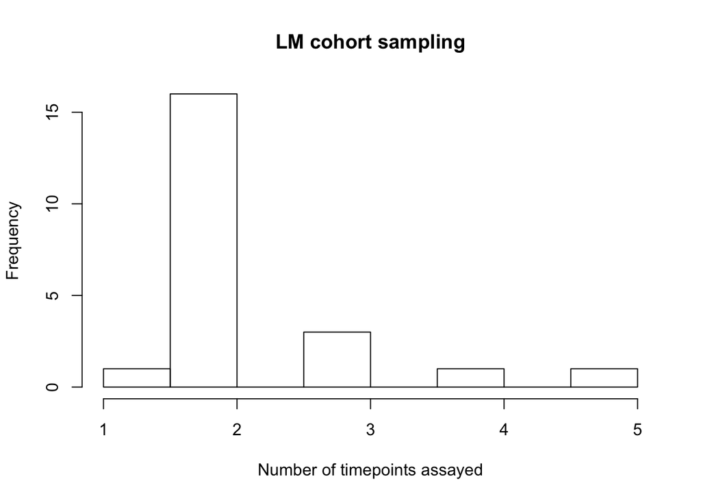

### Calculate divergence

We then calculate divergence for all comparisons of samples and record the organ, timepoint, type of sample (primary and metastasis) and block id for each.

### Calculate PGA and compare to divergence and WGD classifier

Added post-review.

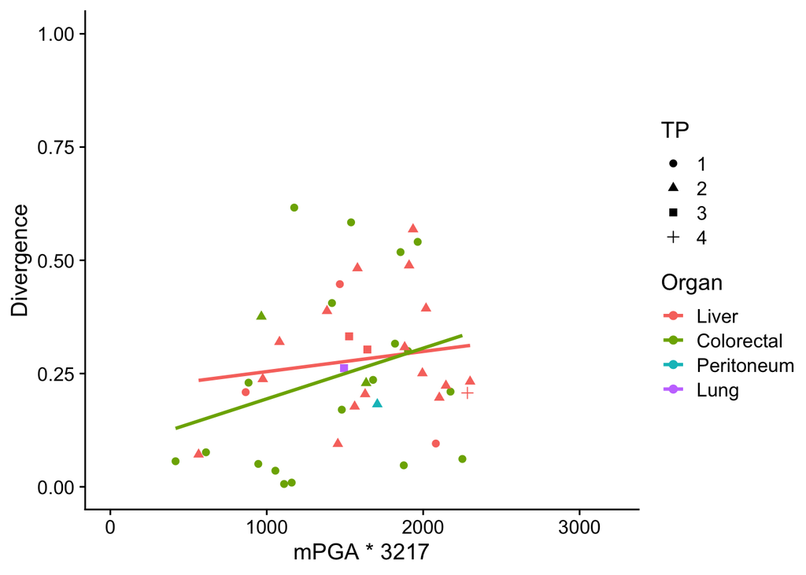

```
##
## Call:
## lm(formula = Divergence ~ mPGA, data = plot.df[plot.df$Organ ==
##     "Colorectal", ])
##
## Residuals:
##      Min       1Q   Median       3Q      Max
## -0.27257 -0.13750 -0.03604  0.16490  0.40254
##
## Coefficients:
##             Estimate Std. Error t value Pr(>|t|)
## (Intercept)  0.08227    0.13033   0.631    0.535
## mPGA         0.35995    0.27779   1.296    0.211
##
## Residual standard error: 0.1971 on 19 degrees of freedom
## Multiple R-squared:  0.08119,    Adjusted R-squared:  0.03284
## F-statistic: 1.679 on 1 and 19 DF,  p-value: 0.2106
```

```
##
## Call:
## lm(formula = Divergence ~ mPGA, data = plot.df[plot.df$Organ ==
##     "Liver", ])
##
## Residuals:
##      Min       1Q   Median       3Q      Max
## -0.20680 -0.09691 -0.02729  0.08617  0.27264
##
## Coefficients:
##             Estimate Std. Error t value Pr(>|t|)
## (Intercept)   0.2098     0.1082   1.940   0.0666 .
## mPGA          0.1431     0.2027   0.706   0.4884
## ---
## Signif. codes:  0 '***' 0.001 '**' 0.01 '*' 0.05 '.' 0.1 ' ' 1
##
## Residual standard error: 0.136 on 20 degrees of freedom
## Multiple R-squared:  0.02431,    Adjusted R-squared:  -0.02447
## F-statistic: 0.4983 on 1 and 20 DF,  p-value: 0.4884
```

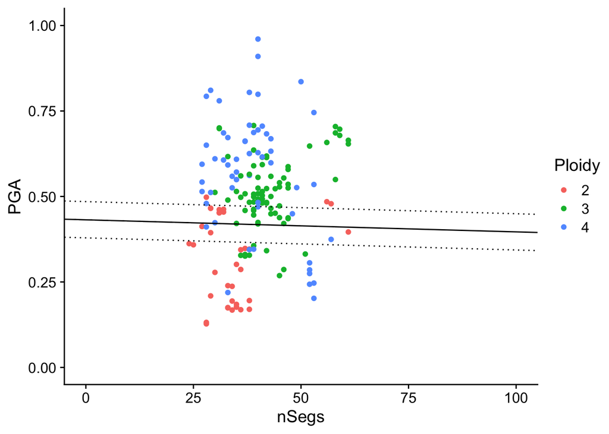

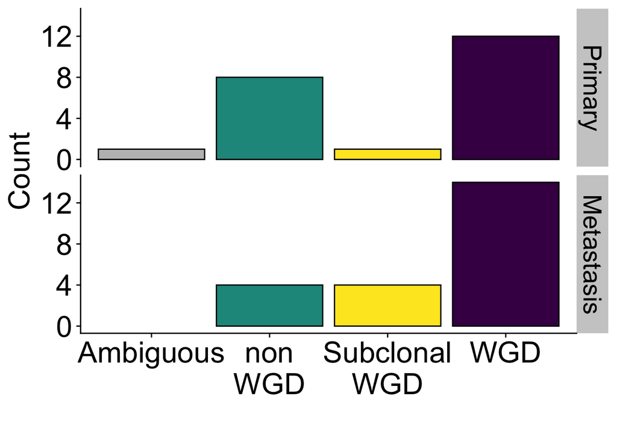

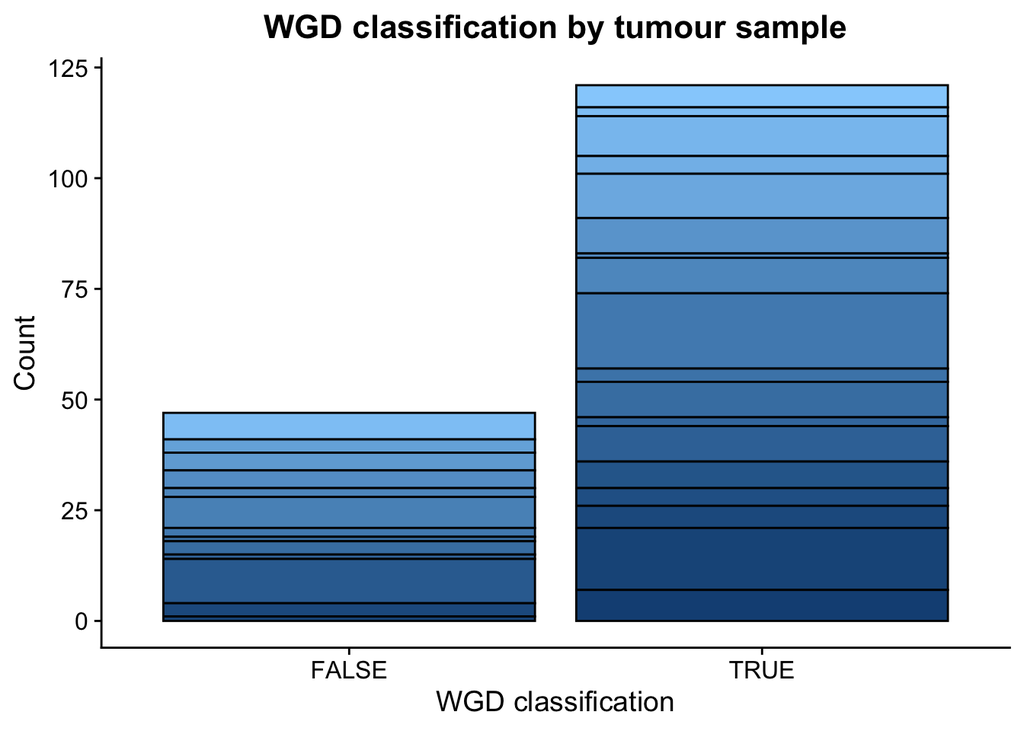

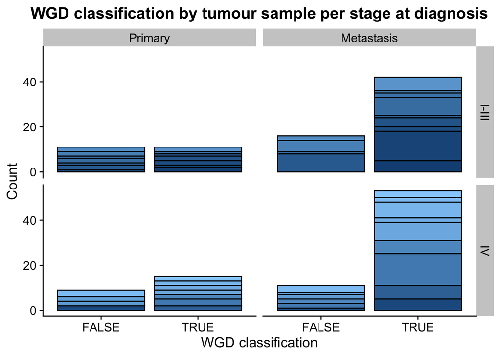

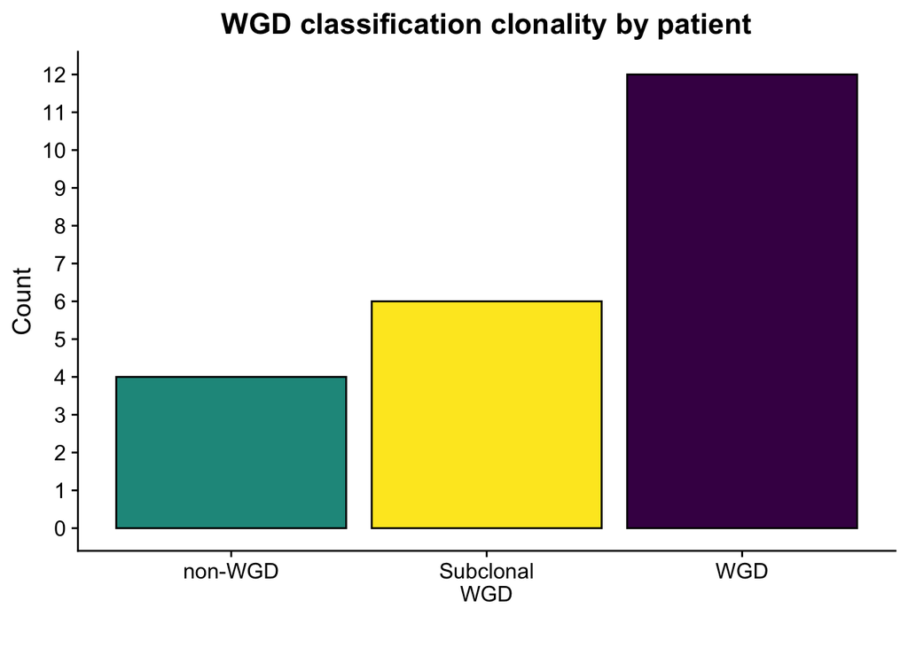

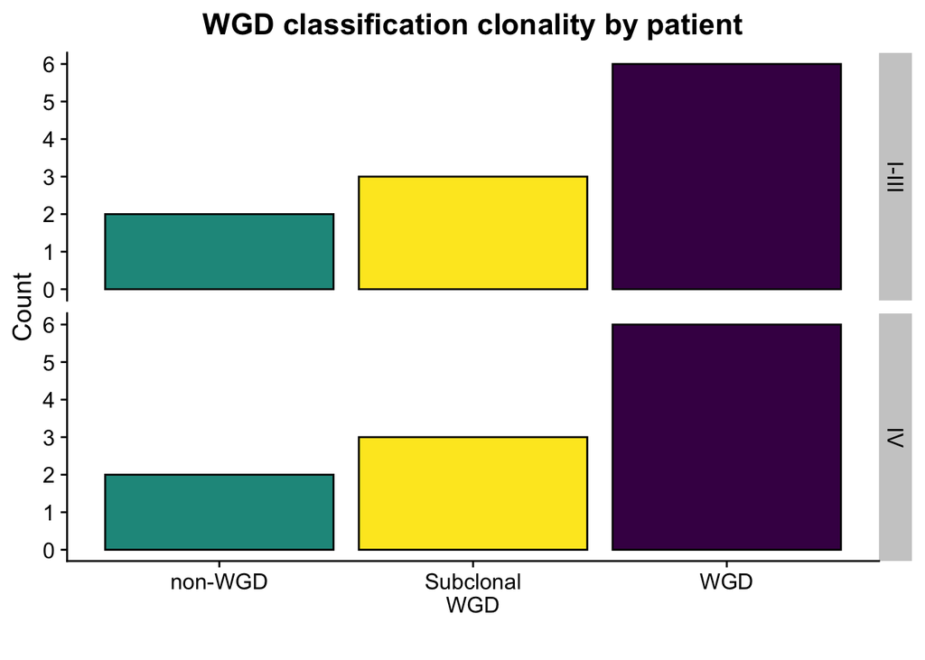

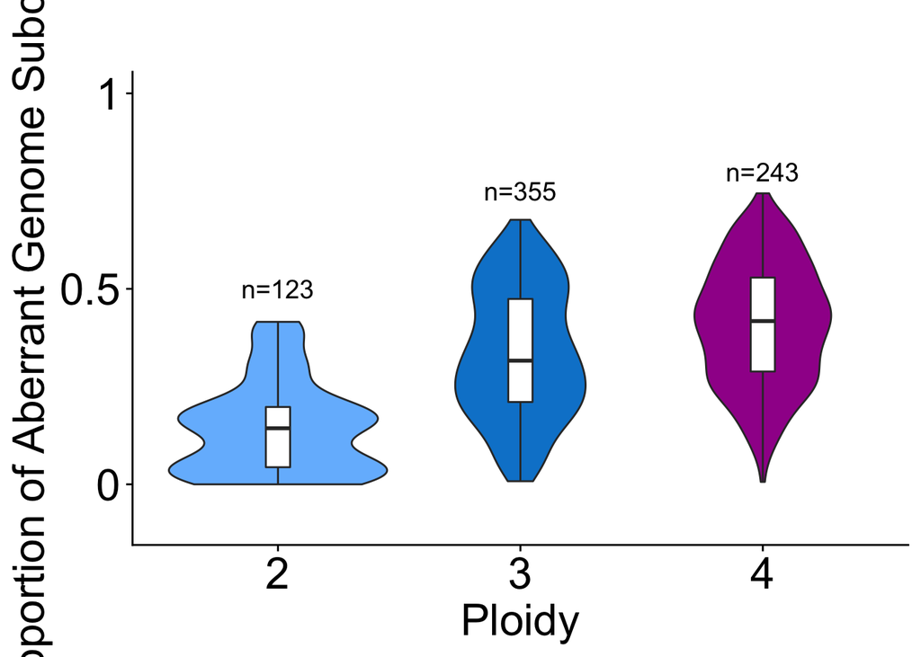

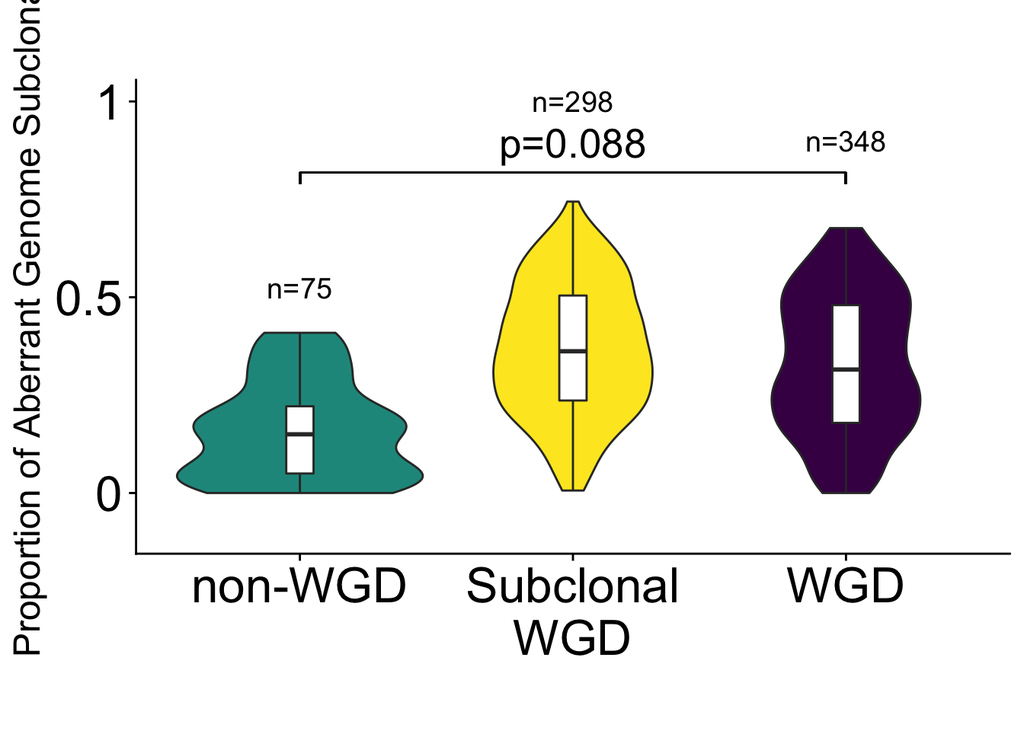

```
##
##     non_WGD subclonal_WGD WGD
##   2       4             0   2
##   3       0             3   6
##   4       0             3   4
```

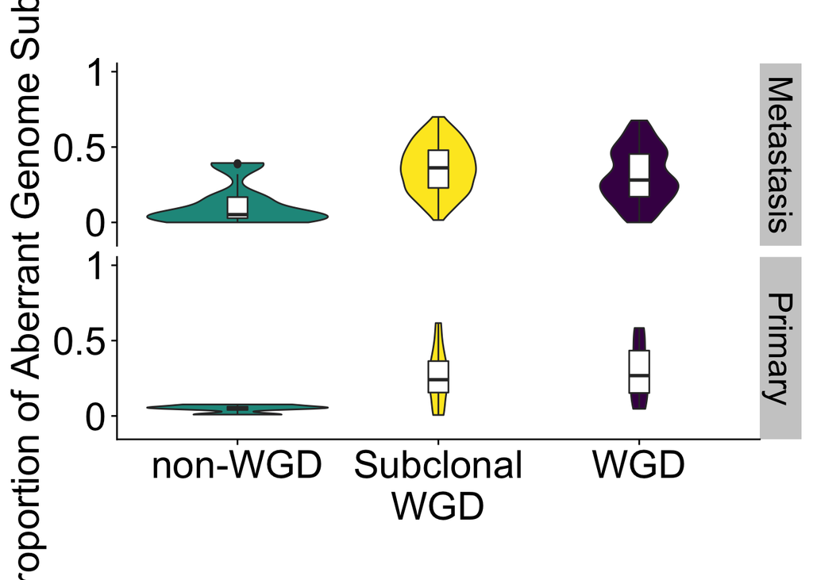

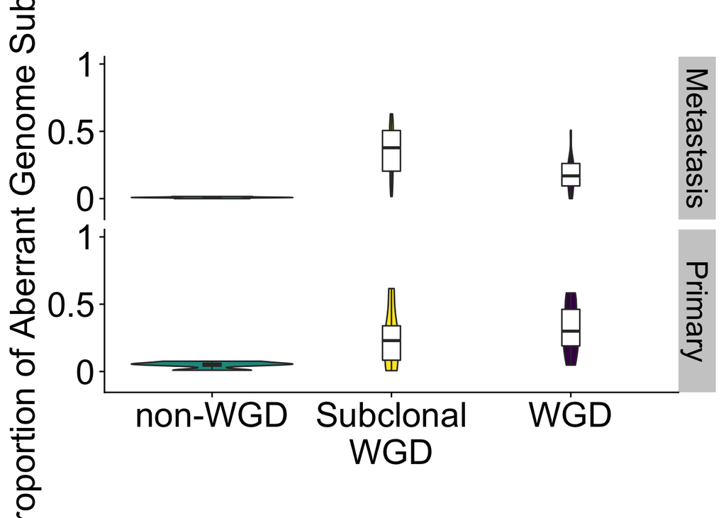

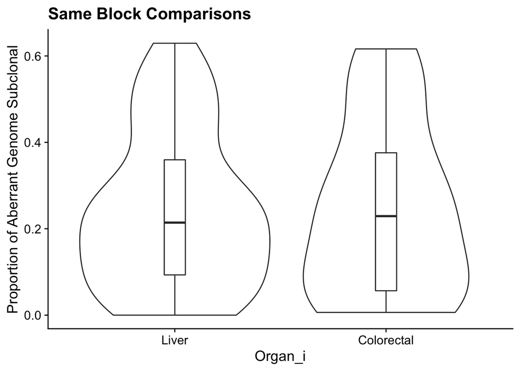

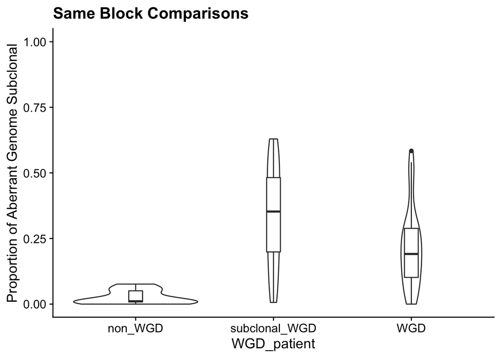

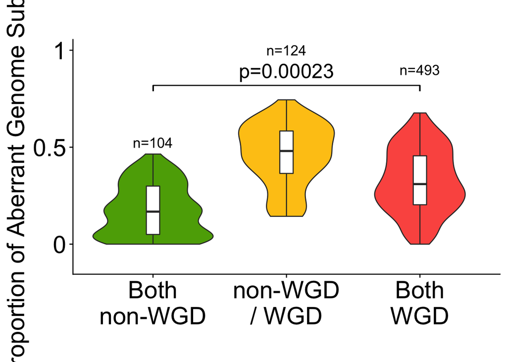

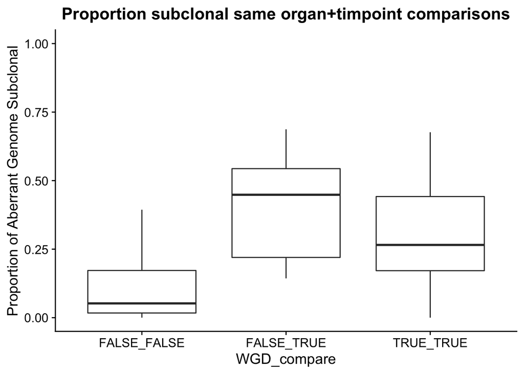

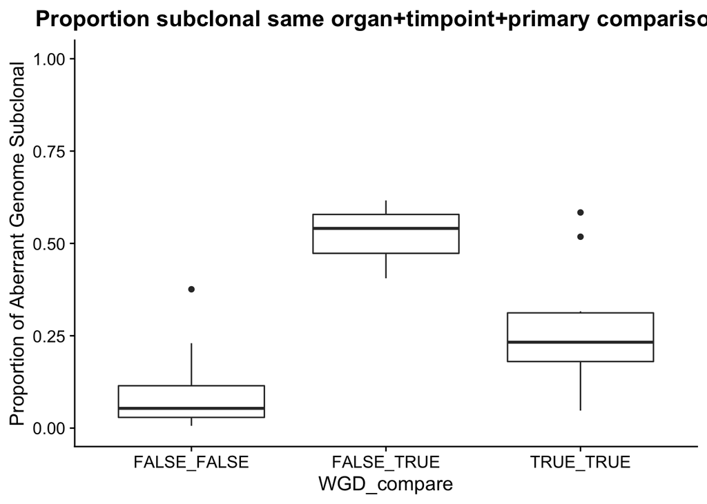

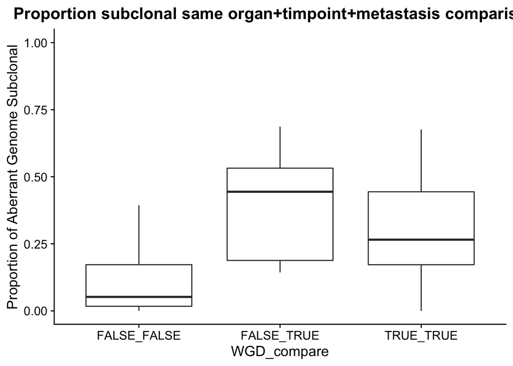

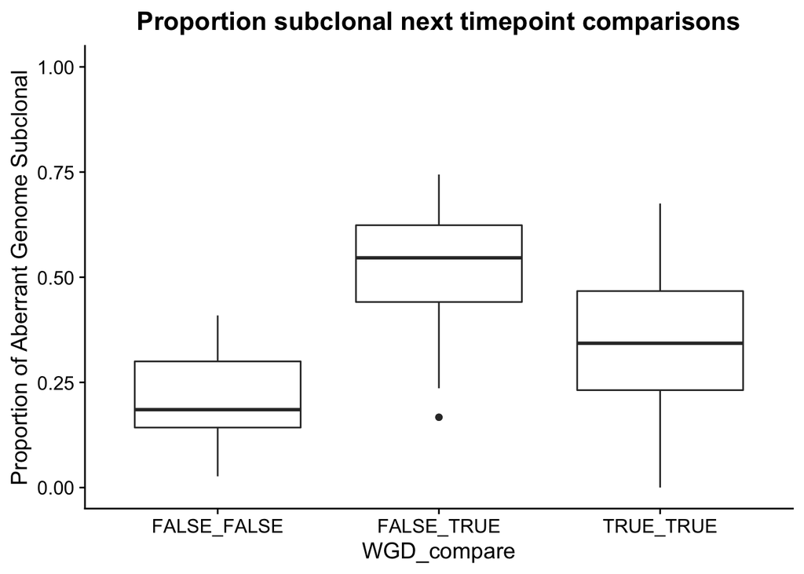

### Mean single timepoint divergence

Next, we calculate the *mean* divergence in each single time interval for each patient and we report the median value. This is provide a value for the general amount of divergence measured.

```
## [1] "Median mean timepoint divergence: 0.351"
```

### Statement for the rebuttal on mean PGA difference seen in colorectal samples

```
## [1] "Mean colorectal PGA difference: 6.54"
```

### Within timepoint, same organ divergence

Here we plot the divergences observed within each single timepoint, within a single organ, to represent divergence in space.

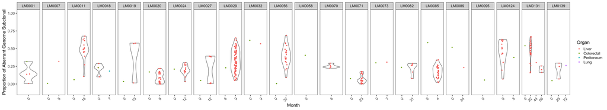

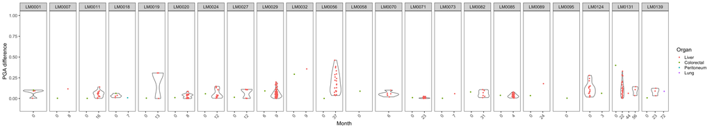

### Same timepoint, difference organ divergence

Here we plot the divergences observed within each single timepoint, but this time within different organs sampled at these timepoints, and this represents divergence in space between the samples across the body. There are very few examples of timepoints in which multiple organs were assessed. Generally in the cohort colorectal samples are sampled in the first timepoint and liver in latter timepoints.

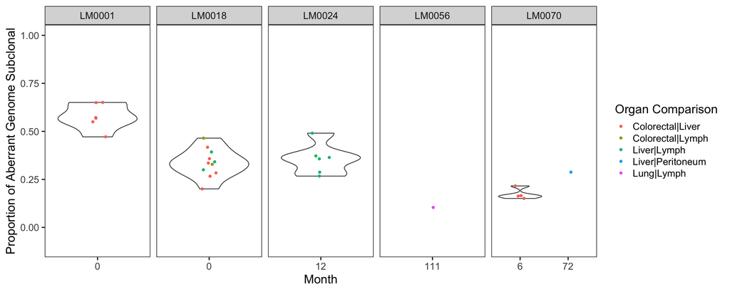

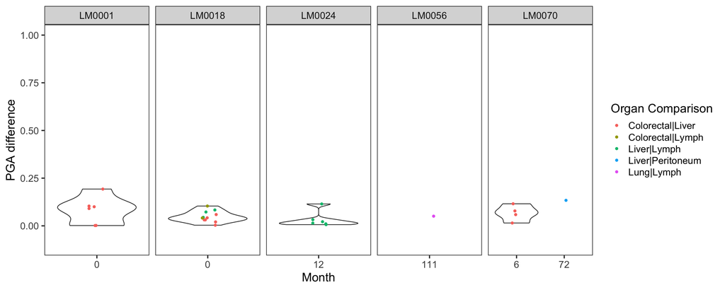

### Mixed model of within organ divergence, primary and metastasis

Of course, to correctly investigate this we need to perform some statistics. Therefore here we create a mixed model (`lmer`) of `Divergence ~ Metastasis` where we use each patient as a random effect to control for the fact that patients may show different total levels of divergence.

```
## [1] "Mixed model (1) - Primary and Metastasis using patients as random intercepts"
```

```
## Linear mixed model fit by REML. t-tests use Satterthwaite's method [
## lmerModLmerTest]
## Formula: dist ~ Type_i + (1 | Patient)
##    Data: within_prim_mets
##
## REML criterion at convergence: -331
##
## Scaled residuals:
##      Min       1Q   Median       3Q      Max
## -2.67977 -0.57193  0.00664  0.63041  3.16093
##
## Random effects:
##  Groups   Name        Variance Std.Dev.
##  Patient  (Intercept) 0.01560  0.1249
##  Residual             0.01849  0.1360
## Number of obs: 334, groups:  Patient, 22
##
## Fixed effects:
##                   Estimate Std. Error        df t value Pr(>|t|)
## (Intercept)        0.24041    0.03994  69.62899   6.020 7.35e-08 ***
## Type_iMetastasis   0.04232    0.03320 331.82564   1.275    0.203
## ---
## Signif. codes:  0 '***' 0.001 '**' 0.01 '*' 0.05 '.' 0.1 ' ' 1
##
## Correlation of Fixed Effects:
##             (Intr)
## Type_Mtstss -0.670
```

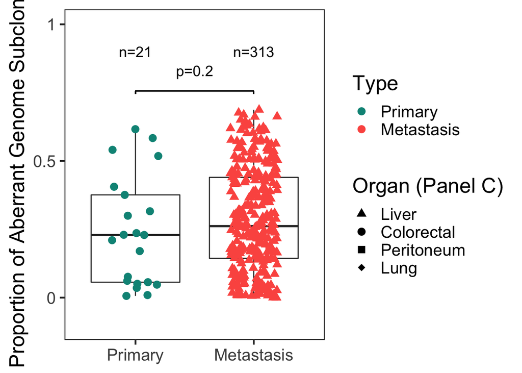

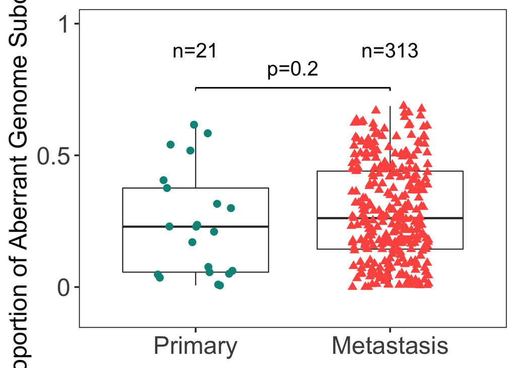

```
## [1] 0.2416781
```

```
## [1] "Repeat of mixed model (1) but for PGA difference"
```

```
## Linear mixed model fit by REML. t-tests use Satterthwaite's method [
## lmerModLmerTest]
## Formula: pdiff ~ Type_i + (1 | Patient)
##    Data: within_prim_mets
##
## REML criterion at convergence: -855.4
##
## Scaled residuals:
##     Min      1Q  Median      3Q     Max
## -2.6675 -0.5348 -0.0935  0.3603  4.8750
##
## Random effects:
##  Groups   Name        Variance Std.Dev.
##  Patient  (Intercept) 0.003467 0.05888
##  Residual             0.003793 0.06159
## Number of obs: 334, groups:  Patient, 22
##
## Fixed effects:
##                   Estimate Std. Error        df t value Pr(>|t|)
## (Intercept)        0.06425    0.01842  55.99321   3.488 0.000956 ***
## Type_iMetastasis   0.01863    0.01507 331.63457   1.236 0.217260
## ---
## Signif. codes:  0 '***' 0.001 '**' 0.01 '*' 0.05 '.' 0.1 ' ' 1
##
## Correlation of Fixed Effects:
##             (Intr)
## Type_Mtstss -0.657
```

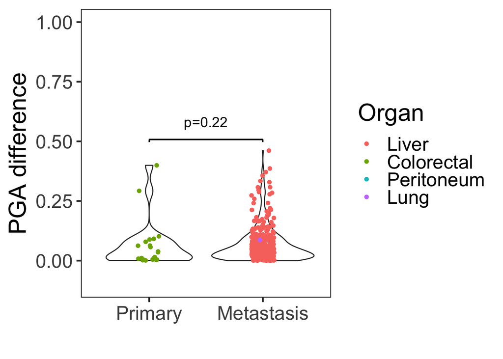

### Compare divergence within colorectal and liver samples and between them

Now we would like to ask if there is a significant difference between divergence within liver and colorectal samples from the same patient and between them. For this we do not filter by timepoint. As we can see there are far fewer colorectal-colorectal comparisons compared to anything to the liver samples.

### ANOVA for difference between intra- and inter- organ variation

So now we ask if any of the categories have a significantly different mean using a simple one-way ANOVA (`aov`).

```
## [1] "An ANOVA for comparing divergence in colorectal and liver organs..."
```

```
##                Df Sum Sq Mean Sq F value  Pr(>F)
## Organ_Compare   2  0.406  0.2032   6.494 0.00161 **
## Residuals     637 19.936  0.0313
## ---
## Signif. codes:  0 '***' 0.001 '**' 0.01 '*' 0.05 '.' 0.1 ' ' 1
```

```
## [1] "An ANOVA for comparing difference in PGA in colorectal and liver organs..."
```

```
##                Df Sum Sq Mean Sq F value  Pr(>F)
## Organ_Compare   2  0.088 0.04420   5.294 0.00525 **
## Residuals     637  5.319 0.00835
## ---
## Signif. codes:  0 '***' 0.001 '**' 0.01 '*' 0.05 '.' 0.1 ' ' 1
```

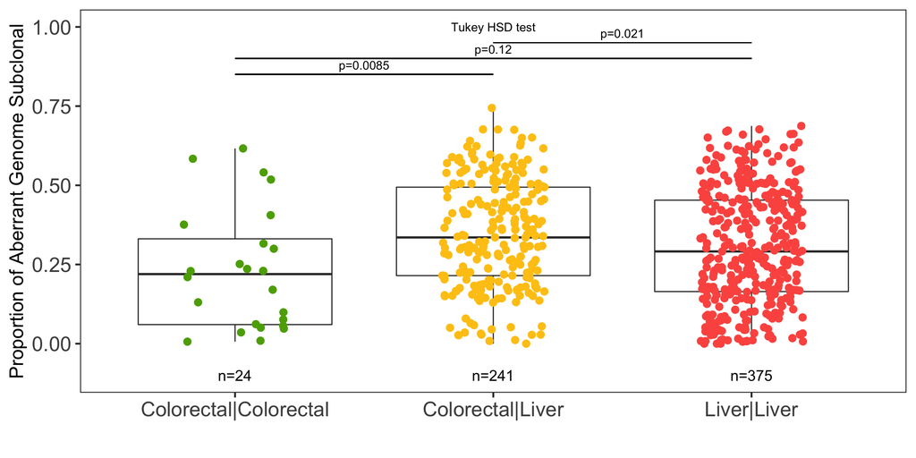

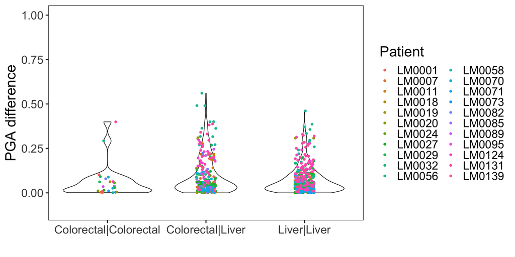

### Divergence found within same timepoint and in different timepoints

Now we want to know if divergence comparisons within timepoints are different from those not in the same timepoint. We now plot this simple category.

To assess this we simply ask what is the effect on divergence if a comparison is made within the same timepoint or not. We again do a mixed model (`lmer`) using the patient as a random effect.

```
## [1] "Mixed model (2) - General assessment of whether within timepoint and across timepoint is different"
```

```
## Linear mixed model fit by REML. t-tests use Satterthwaite's method [
## lmerModLmerTest]
## Formula: dist ~ Same_tp + (1 | Patient)
##    Data: within_tps_across_tps
##
## REML criterion at convergence: -762.9
##
## Scaled residuals:
##      Min       1Q   Median       3Q      Max
## -2.91091 -0.64660  0.00281  0.60701  2.84146
##
## Random effects:
##  Groups   Name        Variance Std.Dev.
##  Patient  (Intercept) 0.01292  0.1137
##  Residual             0.01843  0.1358
## Number of obs: 721, groups:  Patient, 22
##
## Fixed effects:
##              Estimate Std. Error        df t value Pr(>|t|)
## (Intercept)   0.34760    0.02608  23.46285  13.327 1.96e-12 ***
## Same_tpTRUE  -0.05652    0.01048 704.85339  -5.394 9.41e-08 ***
## ---
## Signif. codes:  0 '***' 0.001 '**' 0.01 '*' 0.05 '.' 0.1 ' ' 1
##
## Correlation of Fixed Effects:
##             (Intr)
## Same_tpTRUE -0.195
```

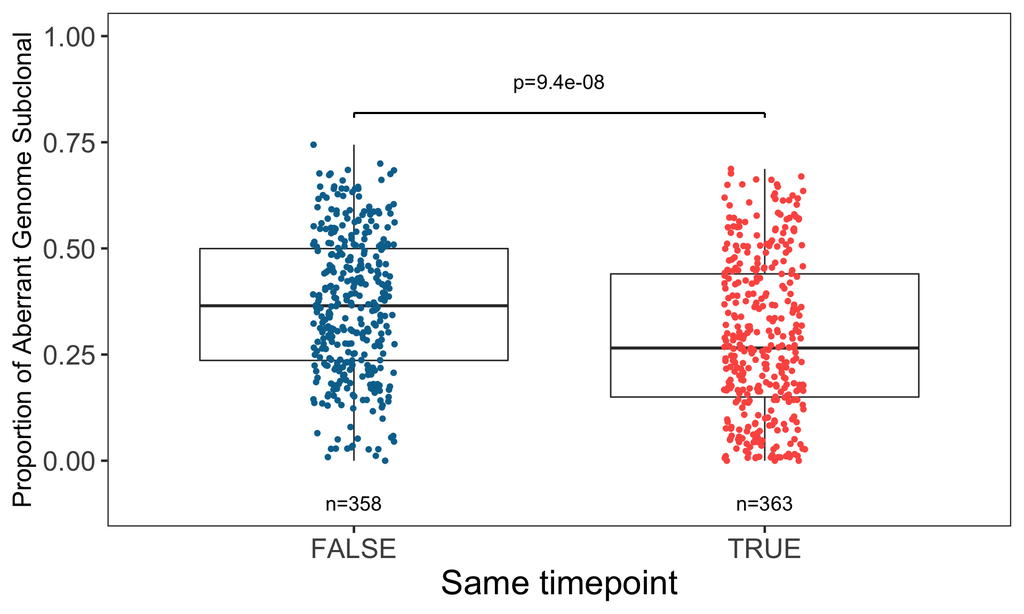

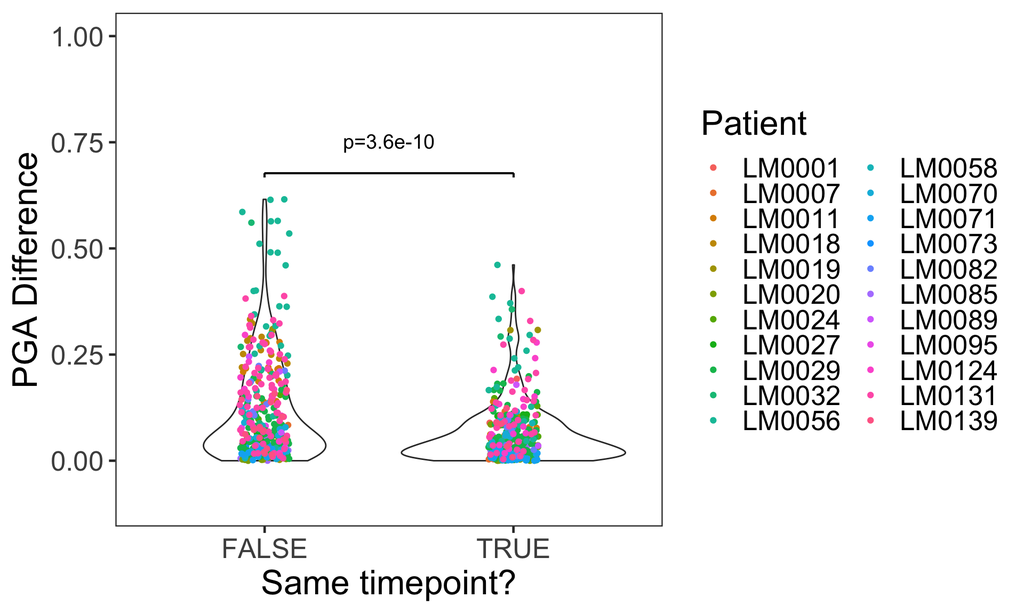